# Fixed effects / Difference-in-differences and Instrumental Variables / Two-stage Least Squares

## 1. Beer Taxes and Traffic Fatalities

During the 1980s, U.S. states pursued a range of strategies to reduce drunk driving. One potential tool is the taxation of alcohol: if beer is more expensive, less should be consumed — potentially saving lives. However, beer taxes vary across states for reasons that may be related to traffic fatality rates, such as revenue needs, political culture, and local attitudes toward alcohol regulation. In addition, states employed other policy levers during this period, including changes to the minimum legal drinking age and mandatory penalties for DUI offenses.

The data below is a panel of the 48 contiguous U.S. states, annually from 1982 through 1988. The traffic fatality rate is the number of traffic deaths per 10,000 population in a given state-year.

| Variable | Definition |
| --- | --- |
| `state` | state identifier (factor) |
| `year` | year (factor) |
| `fatality_rate` | traffic deaths per 10,000 population |
| `afatal_rate` | alcohol-related traffic deaths per 10,000 population |
| `beertax` | tax on a case of beer (dollars) |
| `unemp` | unemployment rate |
| `income` | per capita personal income (dollars) |
| `drinkage` | minimum legal drinking age |
| `breath` | preliminary breath test law (0/1) |
| `jail` | mandatory jail sentence for DUI (0/1) |
| `service` | mandatory community service for DUI (0/1) |
| `spirits` | per capita spirits consumption (gallons) |
| `youngdrivers` | percent of drivers aged 15–24 |
| `pop` | state population |

#### a)

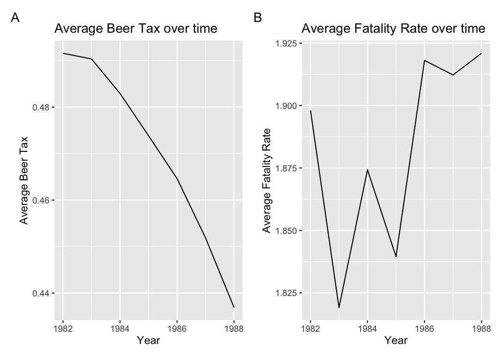

```r
## data for figure
fig <- df %>%
  mutate(year_num = as.numeric(as.character(year))) %>%
  group_by(year) %>%
  summarize(
    avg_tax     = weighted.mean(beertax, w = pop, na.rm = T),
    avg_fatality = weighted.mean(fatality_rate, w = pop, na.rm = T)
  )

## Panel A: Beer tax over time
A <- ggplot(fig, aes(x = year, y = avg_tax)) +
  geom_line() +
  labs(y = "Average Beer Tax", x = "Year", title = "Average Beer Tax over time")

## Panel B: Fatality rate over time
B <- ggplot(fig, aes(x = year, y = avg_fatality)) +
  geom_line() +
  labs(y = "Average Fatality Rate", x = "Year", title = "Average Fatality Rate over time")

## Combine with patchwork
A + B + plot_annotation(tag_levels = 'A')
```

Panel A shows the population-weighted average beer tax over time. Panel B shows the population-weighted average fatality rate over time.

#### b)

A basic specification aimed at estimating the impact of beer taxes on traffic fatalities is:

fatality_rateit = $\alpha$ + $\delta$ * beertaxi + $𝜂_i$

Suppose that $𝜂_{it}$ = $\alpha_i$ + $\alpha_t$ + $\varepsilon_{it}$, where $\alpha_i$ are state fixed effects and $\alpha_t$ are year fixed effects.

$𝛼_i$ may capture state fixed effects or things that are distinct to that specific state. The culture of the state might just be more geared towards beer consumption especially if there are universities in the area. Beer consumption tends to be higher in this case, regardless of beer tax. Climate can also be a factor; states that have heavier snowfall are more prone to traffic accidents.

$𝛼_t$ may capture time fixed effects or things that may have evolved over time. Traffic safety regulations such as seat belt improvements or lowered highway speeds may have an effect on the fatality rate.

We assume that things that are trending across time are common across states, and that things that are specific to the state are the same over time. If one state is stricter toward traffic punishments (e.g. lowering the speed limit), this will confound the effect of beer tax toward fatality rate.

#### c)

```r
## models
models <- list(
  "Model 1: No controls"  = feols(fatality_rate ~ beertax | state + year, data = df, weight = ~pop, cluster = ~state),
  "Model 2: Enforcement controls" = feols(fatality_rate ~ beertax + jail + service + breath + drinkage | state + year, data = df, weight = ~pop, cluster = ~state),
  "Model 3: Enforcement and economic controls" = feols(fatality_rate ~ beertax + jail + service + breath + drinkage + unemp + income | state + year, data = df, weight = ~pop, cluster = ~state),
  "Model 4: Alcohol-related traffic deaths" = feols(afatal_rate ~ beertax + jail + service + breath + drinkage + unemp + income | state + year, data = df, weight = ~pop, cluster = ~state)
)
```

```
## NOTE: 1 observation removed because of NA values (RHS: 1).
## NOTE: 1 observation removed because of NA values (RHS: 1).
## NOTE: 1 observation removed because of NA values (RHS: 1).
```

```r
## table
modelsummary(models,
             stars = T,
             gof_omit = "[^R2|Num.Obs]",
             title = "Traffic deaths per 10,000 population")
```

Traffic deaths per 10,000 population

|  | Model 1: No controls | Model 2: Enforcement controls | Model 3: Enforcement and economic controls | Model 4: Alcohol-related traffic deaths |
| --- | --- | --- | --- | --- |
| beertax | -0.843* | -0.843* | -0.693* | -0.289 |
|  | (0.360) | (0.347) | (0.288) | (0.255) |
| jail |  | -0.007 | 0.012 | 0.225*** |
|  |  | (0.014) | (0.012) | (0.009) |
| service |  | 0.148 | 0.079 | -0.146+ |
|  |  | (0.117) | (0.127) | (0.080) |
| breathyes |  | 0.027 | 0.056* | 0.023 |
|  |  | (0.054) | (0.025) | (0.038) |
| drinkage |  | -0.045 | -0.018 | -0.019 |
|  |  | (0.035) | (0.019) | (0.013) |
| unemp |  |  | -0.076*** | -0.045** |
|  |  |  | (0.010) | (0.015) |
| income |  |  | 0.000* | 0.000 |
|  |  |  | (0.000) | (0.000) |
| Num.Obs. | 336 | 335 | 335 | 335 |
| R2 | 0.923 | 0.926 | 0.957 | 0.863 |

+ p < 0.1, * p < 0.05, ** p < 0.01, *** p < 0.001

#### d)

```r
## magnitude calculation
## hint: use quantile() to find the 25th and 75th percentiles of beertax,
## then multiply the difference by your estimated coefficient.
Q <- quantile(df$beertax, c(0.25, 0.75))
show(Q)
```

```
##       25%       75%
## 0.2088493 0.6515735
```

Difference / IQR = 0.4427242  
Multiplied by the coefficient in Model 1 and 2 = -0.3732165

If the state were to raise the beer tax from the 25th to 75th percentile, the fatalities would decrease by roughly 0.3 per 10,000 people in a year.

## 2. Retirement Savings and Crowding Out

Encouraging people to save for retirement is a major goal of policy makers. In this question, we investigate whether employer-sponsored savings plans crowd out private saving.

An Individual Retirement Account (IRA) is a tax-advantaged retirement savings account that individuals set up on their own. A 401(k) is an employer-sponsored retirement plan. Policy makers have speculated that participation in a 401(k) might “crowd out” saving through other channels, such as an IRA. We ask: does participation in a 401(k) make it *less likely* that one will set up an IRA? Assume constant treatment effects.

The basic specification is: *pira*<sub>i</sub> = $\alpha$ + $\delta$ * *p401k*<sub>i</sub> + $𝜂_i$

#### a)

$Y_{0i}$ - individual’s participation in IRA given that they have a 401k  
$Y_{1i}$ - individual’s non-participation in IRA given that they have a 401k

Individual treatment effect: $Y_{0i}$ - $Y_{1i}$ or 𝛿

#### b)

Omitted variable bias formula:  
E($𝜂_i$ | $D_i$, $X_i$, $A_i$) = E($𝜂_i$ | $X_i$, $A_i$) = $X'_i$𝛽 + 𝛾$A_i$  
where $A_i$ is the omitted variable or ability that we cannot observe (e.g. risk aversion)

If the individual is more risk averse or more likely to save, regardless of the treatment (opening a 401K account), it will bias the estimate upward. We might attribute the individual’s decision to open an IRA account due to the treatment, whereas they might just be more inclined to save.

#### c)

```r
## models
models <- list(
  "Model 1: No controls" = feols(pira ~ p401k, data = df2, se = "hetero"),
  "Model 2: Economic controls" = feols(pira ~ p401k + inc + incsq + age + agesq + marr + fsize, data = df2, se = "hetero")
)

## table
modelsummary(models,
             stars = T,
             gof_omit = "AIC|BIC|Log.Lik.|F|R2 Pseudo|R2 Within")
```

|  | Model 1: No controls | Model 2: Economic controls |
| --- | --- | --- |
| (Intercept) | 0.212*** | -0.397** |
|  | (0.009) | (0.121) |
| p401k | 0.158*** | 0.050** |
|  | (0.020) | (0.019) |
| inc |  | 0.009*** |
|  |  | (0.001) |
| incsq |  | -0.000*** |
|  |  | (0.000) |
| age |  | 0.010+ |
|  |  | (0.006) |
| agesq |  | -0.000 |
|  |  | (0.000) |
| marr |  | 0.022 |
|  |  | (0.020) |
| fsize |  | -0.026*** |
|  |  | (0.005) |
| Num.Obs. | 2782 | 2782 |
| R2 | 0.026 | 0.194 |
| R2 Adj. | 0.026 | 0.192 |
| RMSE | 0.43 | 0.39 |
| Std.Errors | Heteroskedasticity-robust | Heteroskedasticity-robust |

+ p < 0.1, * p < 0.05, ** p < 0.01, *** p < 0.001

Participation in 401k is associated with a 15.8% increase in IRA participation. When controlling for economic demographics, participation in 401k is now associated with only a 5% increase in IRA participation.

#### d)

`e401k` must satisfy the relevance and exclusion conditions. Eligibility must be correlated with participation in 401k, which makes sense as you cannot participate in a 401k if you are not eligible. Eligibility should not be correlated to participation in IRA. This is less plausible than the first condition. Being employed in a company that offers a 401k might just make the individual more aware of the benefits of saving (i.e. if they are working for a financial company) and are therefore more inclined to save.

#### e)

```r
## first stage
models <- list(
  feols(p401k ~ e401k, data = df2, se = "hetero"),
  feols(p401k ~ e401k + inc + incsq + age + agesq + marr + fsize, data = df2, se = "hetero")
)

modelsummary(models,
             stars = T,
             gof_omit = "AIC|BIC|Log.Lik.|F|R2 Pseudo|R2 Within")
```

|  | (1) | (2) |
| --- | --- | --- |
| (Intercept) | -0.000 | -0.005 |
|  | (0.000) | (0.087) |
| e401k | 0.723*** | 0.707*** |
|  | (0.014) | (0.014) |
| inc |  | 0.001+ |
|  |  | (0.001) |
| incsq |  | -0.000 |
|  |  | (0.000) |
| age |  | -0.003 |
|  |  | (0.004) |
| agesq |  | 0.000 |
|  |  | (0.000) |
| marr |  | 0.015 |
|  |  | (0.015) |
| fsize |  | -0.002 |
|  |  | (0.004) |
| Num.Obs. | 2782 | 2782 |
| R2 | 0.615 | 0.620 |
| R2 Adj. | 0.615 | 0.619 |
| RMSE | 0.28 | 0.28 |
| Std.Errors | Heteroskedasticity-robust | Heteroskedasticity-robust |

+ p < 0.1, * p < 0.05, ** p < 0.01, *** p < 0.001

#### f)

```r
## 2SLS
## recall feols IV syntax: feols(y ~ exogenous | endogenous ~ instrument)
models <- list(
  feols(pira ~ 1 | p401k ~ e401k, data = df2, se = "hetero"),
  feols(pira ~ inc + incsq + age + agesq + marr + fsize | p401k ~ e401k, data = df2, se = "hetero")
)

modelsummary(models,
             stars = T,
             gof_omit = "AIC|BIC|Log.Lik.|F|R2 Pseudo|R2 Within")
```

|  | (1) | (2) |
| --- | --- | --- |
| (Intercept) | 0.215*** | -0.414*** |
|  | (0.010) | (0.122) |
| fit_p401k | 0.147*** | 0.008 |
|  | (0.024) | (0.024) |
| inc |  | 0.010*** |
|  |  | (0.001) |
| incsq |  | -0.000*** |
|  |  | (0.000) |
| age |  | 0.011+ |
|  |  | (0.006) |
| agesq |  | -0.000 |
|  |  | (0.000) |
| marr |  | 0.021 |
|  |  | (0.020) |
| fsize |  | -0.026*** |
|  |  | (0.005) |
| Num.Obs. | 2782 | 2782 |
| R2 | 0.014 | 0.192 |
| R2 Adj. | 0.014 | 0.190 |
| RMSE | 0.43 | 0.39 |
| Std.Errors | Heteroskedasticity-robust | Heteroskedasticity-robust |

+ p < 0.1, * p < 0.05, ** p < 0.01, *** p < 0.001

Participation in 401k does not seem to crowd out participation in IRA. 401k participation is associated with a 14.7% increase in IRA participation. If there was crowding out, we would expect to see a negative coefficient for p401k. The same is true when controls are included, although with a weaker result. 401k participation increases IRA participation by .8%.

#### g)

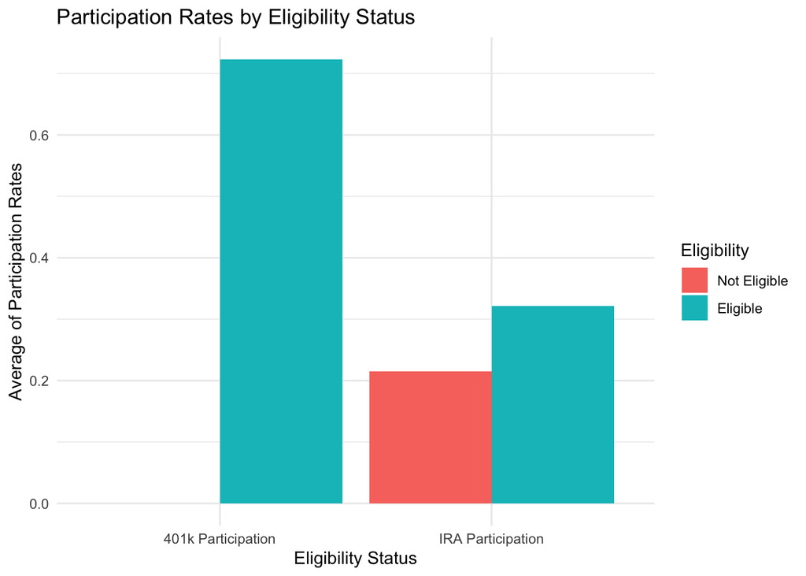

```r
## step 1: summarize participation rates
fig_data <- df2 %>%
  group_by(e401k) %>%
  summarize(
    `401k Participation` = mean(p401k),
    `IRA Participation`  = mean(pira)
  )

## step 2: pivot to long format
fig_data <- fig_data %>%
  pivot_longer(
    cols = c('401k Participation', 'IRA Participation'),
    names_to  = "type",
    values_to = "values"
  ) %>%
  mutate(e401k = factor(e401k, labels = c("Not Eligible", "Eligible")))

## step 3: plot
ggplot(fig_data, aes(x = type, y = values, fill = e401k)) +
  geom_col(position = "dodge") +
  labs(
    x     = "Eligibility Status",
    y     = "Average of Participation Rates",
    fill  = "Eligibility",
    title = "Participation Rates by Eligibility Status"
  ) +
  theme_minimal()
```

Individuals who are ineligible for a 401k have lower IRA participation rates than those who are eligible for a 401k. So individuals who are eligible for a 401k also tend to open an IRA. There is no evidence of crowding out.